# Case Study Template (Rough Draft)

2026-07-28

## Terminology

**Regression AGWRC**: the AGWRC calculated by imputing starting flow from manually selected flow event into AGWRC vs Flow Regression

**Event AGWRC**: the AGWRC from a known baseflow event identified by the workflow

**Iterative AGWRC**: the manually selected AGWRC that provides the “best fit” for the manually selected baseflow event

**Starting flow**: the observed flow at the first day of the manually selected baseflow event

**MAE**: Mean Absolute Error

**RMSE**: Root Mean Square Error

**MAPE**: Mean Absolute Percentage Error

## Current Forecast

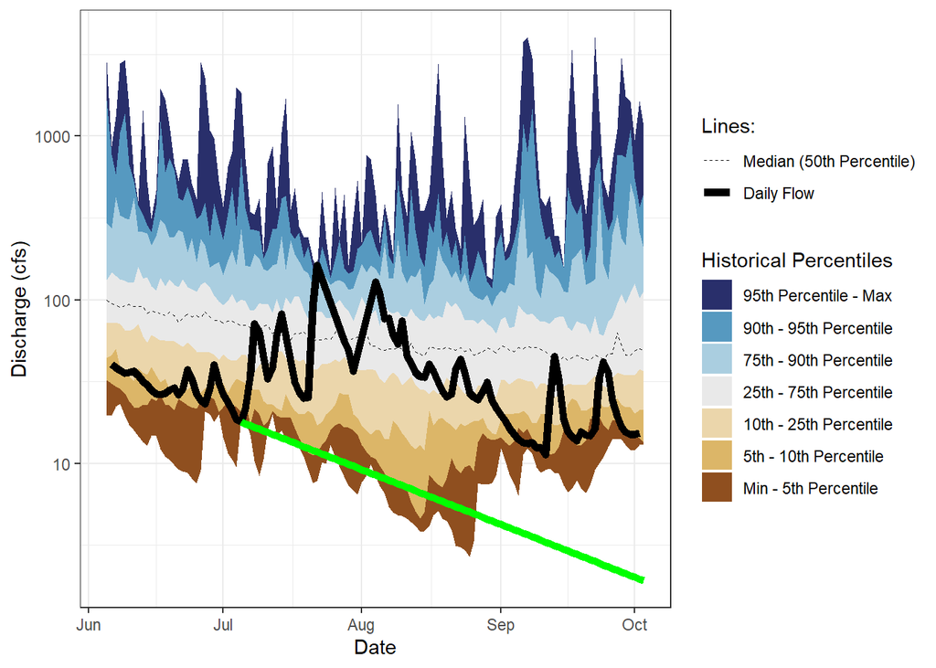

**Figure 1.** Current baseflow forecast at USGS 02056900 based on a variably calculated AGWRC.

**Table 1.** Current baseflow forecast flow projections at USGS 02056900 based on a variably calculated AGWRC.

| Day | Date | AGWRC | Forecast | Observed | Percentile |
| --- | --- | --- | --- | --- | --- |
| 15 | 2026-07-20 | 0.9754527 | 12.345058 | 25.2 | 1.56% |
| 30 | 2026-08-04 | 0.9754527 | 8.503273 | 129.0 | 3.43% |
| 45 | 2026-08-19 | 0.9754527 | 5.857052 | 27.7 | 2.07% |
| 90 | 2026-10-03 | 0.9754527 | 1.914071 | 15.3 | 0% |

## Annual Low Flow Plot

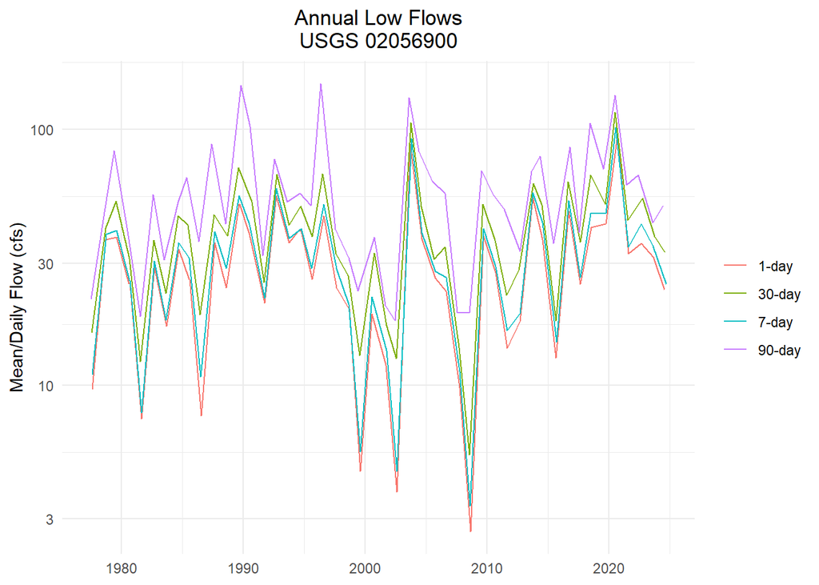

**Figure 3.** Annual low flow plot for 1-day, 7-day, 30-day, and 90-day low flows at USGS 02056900 showing the droughts on record.

## Lowest One-Day Flow

The lowest one-day flow on record for USGS 02056900 is 2.68 cfs, which occurred on 2008-08-25. The plot below shows the projected forecast using the variable, constant, and iterative AGWRC methods from a start date that is automatically adjusted to begin at the the lowest flow that occurs between the months of the previous May and July (if the lowest day flow occurs outside of that date range).

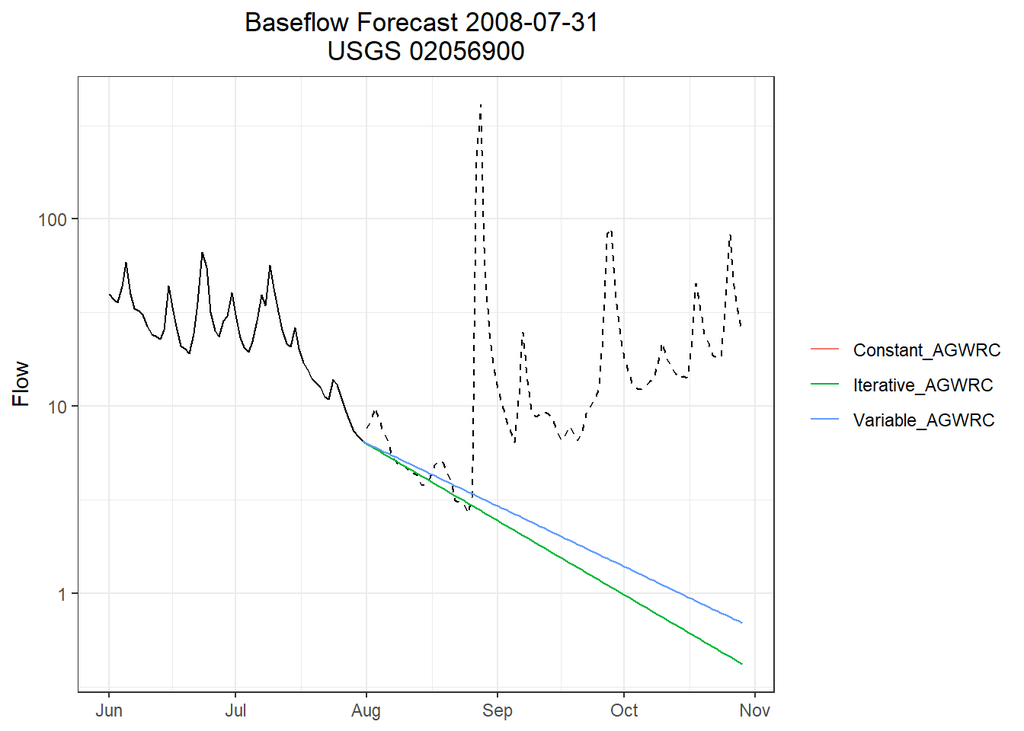

## Non-Exceedance Probability Table

Non-Exceedance Probability is the statistical chance that stream flow is recorded at or below a specific value. A 5% NEP of 40 cfs indicates that stream flow will be at or below 40 cfs 5% of the time.

| Month | Min | 5% | 10% | 25% | 30% | 50% | Mean |
| --- | --- | --- | --- | --- | --- | --- | --- |
| Jan | 21.00 | 41.97 | 51.00 | 73.00 | 82.00 | 111.00 | 156.0 |
| Feb | 31.00 | 49.52 | 58.25 | 86.00 | 95.00 | 123.00 | 171.9 |
| Mar | 29.70 | 60.00 | 73.36 | 102.00 | 108.00 | 140.00 | 191.5 |
| Apr | 39.00 | 60.99 | 68.00 | 89.50 | 96.60 | 137.00 | 204.9 |
| May | 25.60 | 46.00 | 55.00 | 81.05 | 89.77 | 118.00 | 151.3 |
| Jun | 7.55 | 26.00 | 34.59 | 57.40 | 64.00 | 86.00 | 134.3 |
| Jul | 6.50 | 18.72 | 25.00 | 41.23 | 46.10 | 63.15 | 84.4 |
| Aug | 2.68 | 10.06 | 18.00 | 30.90 | 34.50 | 50.00 | 72.5 |
| Sep | 6.37 | 15.00 | 20.00 | 30.08 | 34.00 | 46.15 | 98.7 |
| Oct | 9.78 | 18.10 | 27.00 | 38.23 | 41.00 | 54.00 | 99.6 |
| Nov | 18.80 | 31.00 | 34.00 | 49.00 | 52.00 | 68.65 | 121.5 |
| Dec | 20.90 | 33.32 | 43.60 | 58.00 | 64.00 | 98.00 | 132.0 |

## Baseflow Analysis

The following baseflow investigations are based on user-defined start dates. Similar to the current forecast and the lowest one-day flow, these start dates are automatically adjusted to begin at the the lowest flow that occurs between the months of the previous May and July and to project flows 90 days beyond this date.

### First Baseflow Event Investigation

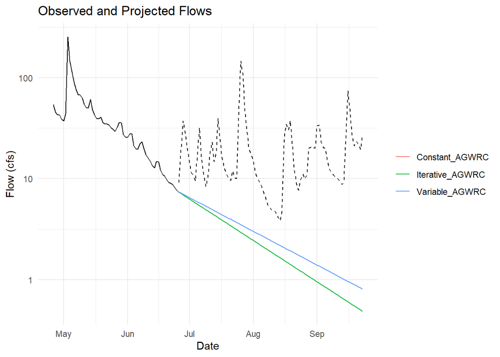

**Figure 4.** Observed and projected flows for USGS 02056900 from 2002-06-25

**Table 2.** Constant, variable, and iterative AGWRC flow forecasts for USGS 02056900 from 2002-06-25

| Day | Date | Obs_Flow | Con_AGWRC_Flow | Var_AGWRC_Flow | Itr_AGWRC_Flow |
| --- | --- | --- | --- | --- | --- |
| 15 | 2002-07-10 | 10.60 | 5.20 | 5.20 | 4.78 |
| 30 | 2002-07-25 | 46.70 | 3.58 | 3.58 | 3.03 |
| 45 | 2002-08-09 | 5.17 | 2.47 | 2.47 | 1.92 |
| 90 | 2002-09-23 | 27.00 | 0.81 | 0.81 | 0.49 |

### Fourth Baseflow Event Investigation

```
## Forecast comparison plot skipped: need 4 forecasts, found 1
```

## Prediction Accuracy Analysis

Below is a summary of common forecast accuracy metrics that highlight the difference between predicted and actual flow values for each identified baseflow event at USGS 02056900. Each of these methods emphasize different aspects of error and should be interpreted together.

### MAE, RMSE, MAPE, Bias, and $R^2$ Analysis

Both MAE and RMSE are scale-dependent metrics. MAE provides the absolute difference between actual and predicted flow values without indicating relative error size. RMSE provides the square root of the average squared error. Unlike MAE which ignores the magnitude of outliers, RMSE penalizes large errors more heavily.

MAPE is a scale-independent metric that provides the average absolute error as a percentage of the actual flow value. However, the MAPE calculation fails if the actual flow value is zero and produces unrealistically high values when the actual flow value is close to zero. This can be an issue for small gages that occasionally run dry or approach extreme low-flow condition. MAPE also tends to over-penalize over- and under-forecasting.

Forecast bias provides an average error where a positive value is indicative of over-forecasting flow and a negative value is indicative of under-forecasting flow.

The R-squared value, or coefficient of determination, explains the proportion of variance in the actual flow values that is explained by the predicted flow values. This shows how well the model captures any patterns in the data. A value of 1 or -1 suggests a perfect fit while a value of 0 suggests that the model does no better than predicting the mean flow value each time.

**Table 6.** Calculations of the MAE, RMSE, MAPE, Bias, and $R^2$ values for all USGS 02056900 GroupIDs

| Statistic | MAE | RMSE | MAPE | Bias | r2 |
| --- | --- | --- | --- | --- | --- |
| Mean | 10.21 | 17.72 | 9.54 | -0.38 | 0.73 |
| Median | 6.51 | 7.26 | 8.34 | 0.40 | 0.93 |
| Min | 0.98 | 1.11 | 2.21 | -80.93 | 0.01 |
| Max | 89.44 | 324.21 | 31.46 | 31.32 | 0.99 |
| Std Dev | 14.56 | 51.05 | 6.53 | 16.17 | 0.32 |

**Table 7.** All GroupIDs with an MAPE over 20%. These events did not perform well and further analysis with these events should be preceded with caution.

| GroupID | MAE | RMSE | MAPE | Bias | r2 |
| --- | --- | --- | --- | --- | --- |
| 5 | 13.34 | 13.96 | 22.66 | 13.34 | 0.99 |
| 19 | 9.45 | 9.64 | 31.46 | 9.45 | 0.98 |
| 20 | 7.05 | 7.29 | 21.81 | 7.05 | 0.96 |
| 30 | 21.19 | 23.55 | 23.55 | 14.80 | 0.09 |

## Case Studies

Below are recorded case studies conducted by DEQ employees. These case studies are typically done for historical low flow years in Virginia, such as 2023, 2008, 2007, 2002, 1998, and 1966. Additional years may be investigated based on historical low flows at the particular gage of interest. These case studies provide insight into gage behavior at low flow conditions to aid in selecting the most appropriate projection method for making current forecasts. The selected projection method (Variable AGWRC, Constant AGWRC, or BPJ AGWRC) is included on each plot (if applicable), and a brief commentary and analysis is written below each plot.

```
## No projection available
```

[figure not shown]

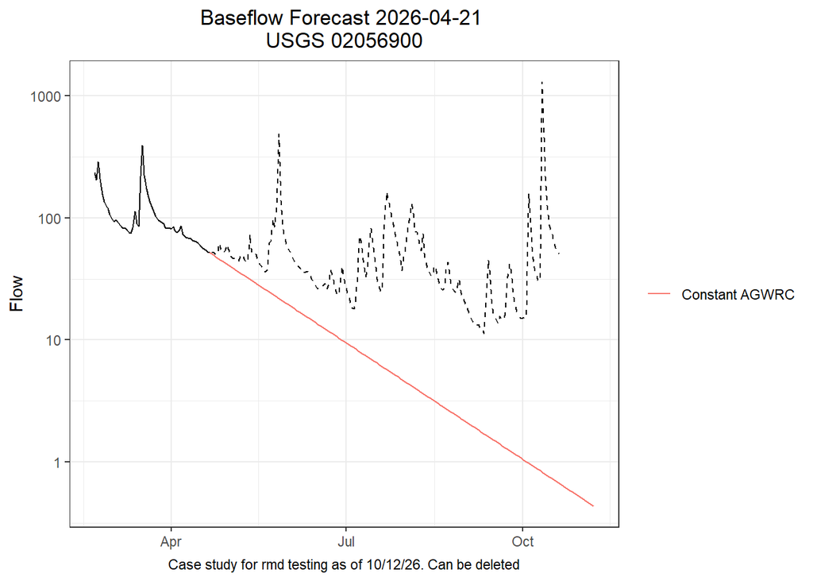

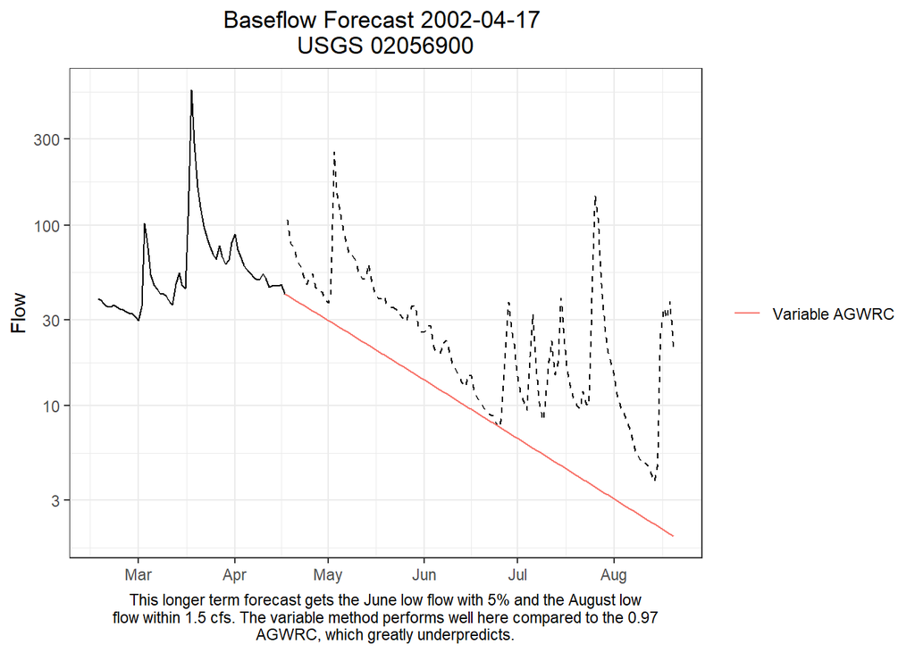

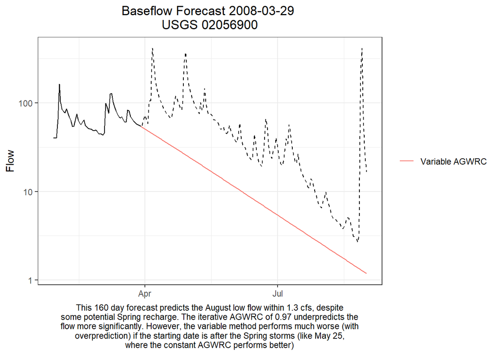

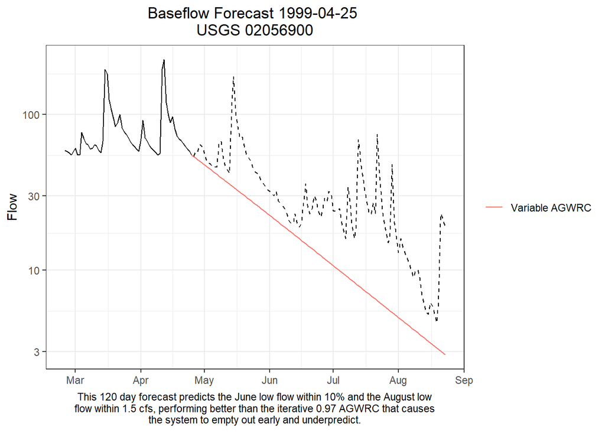

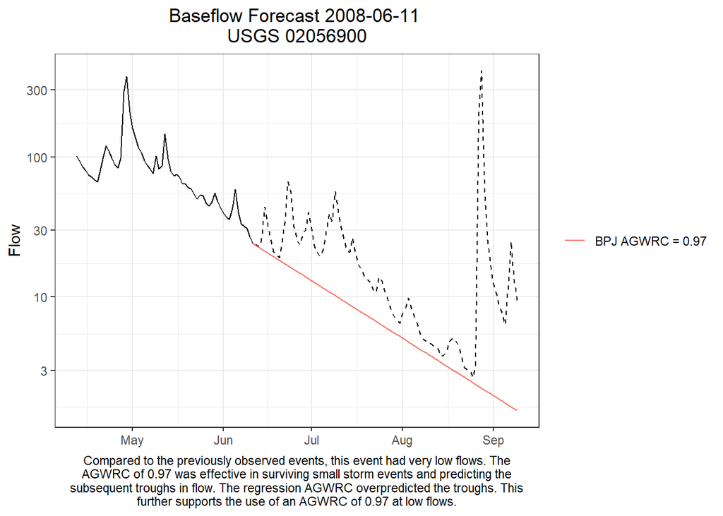

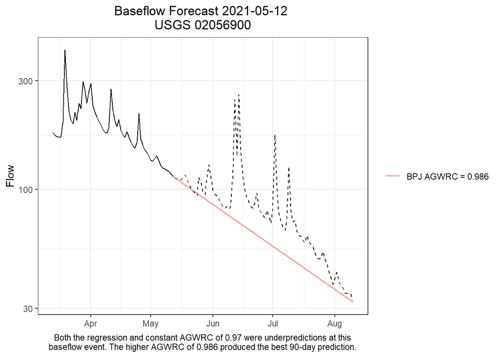

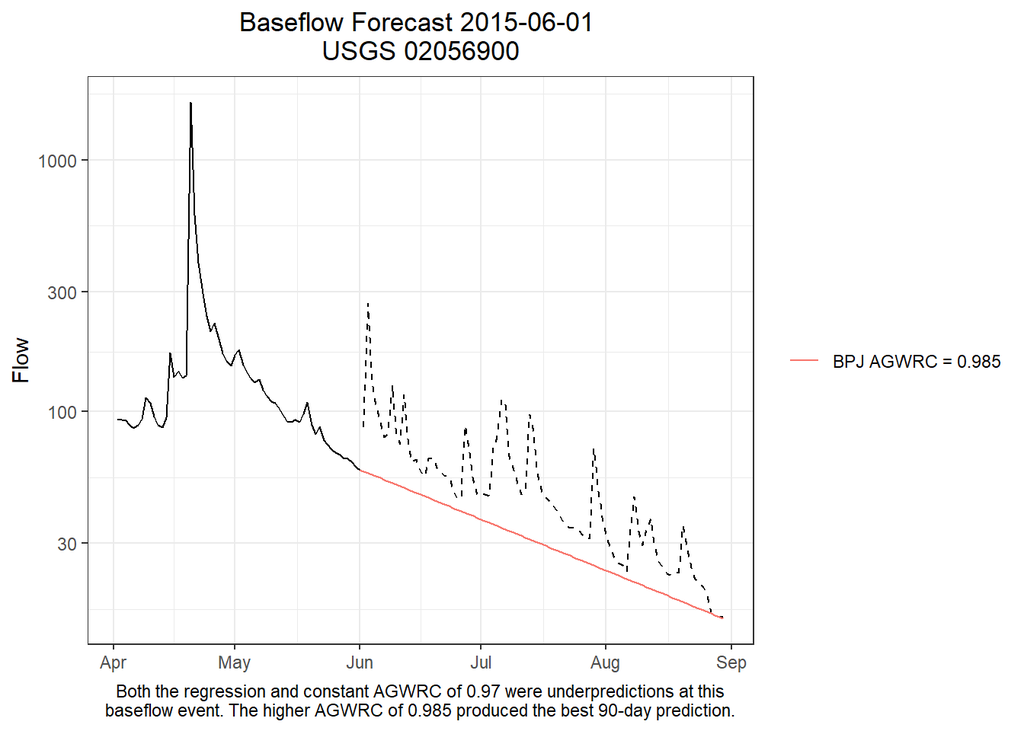

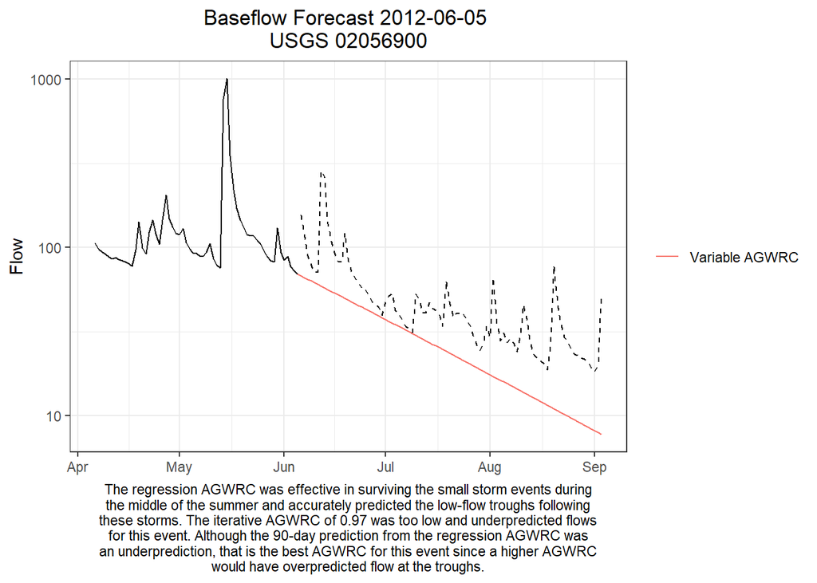

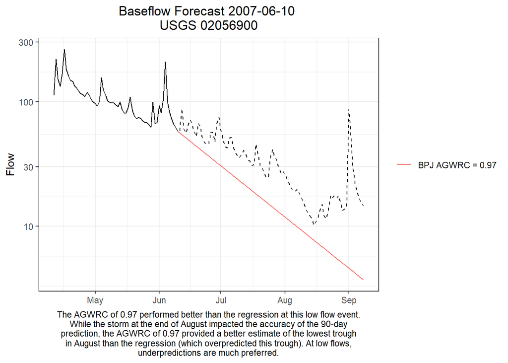

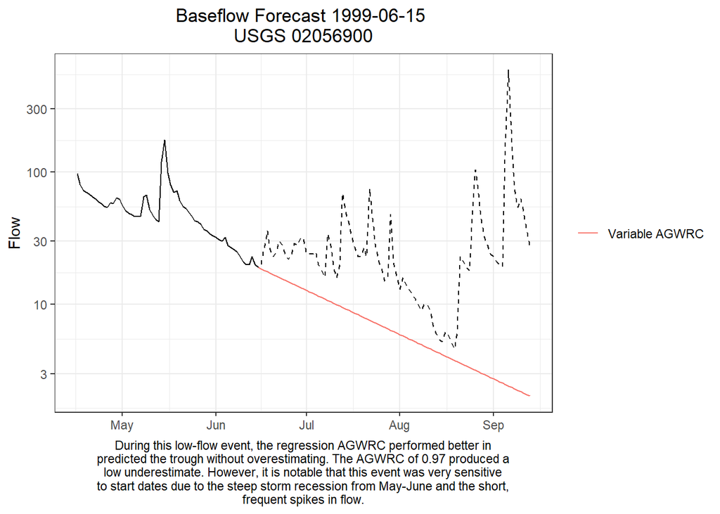

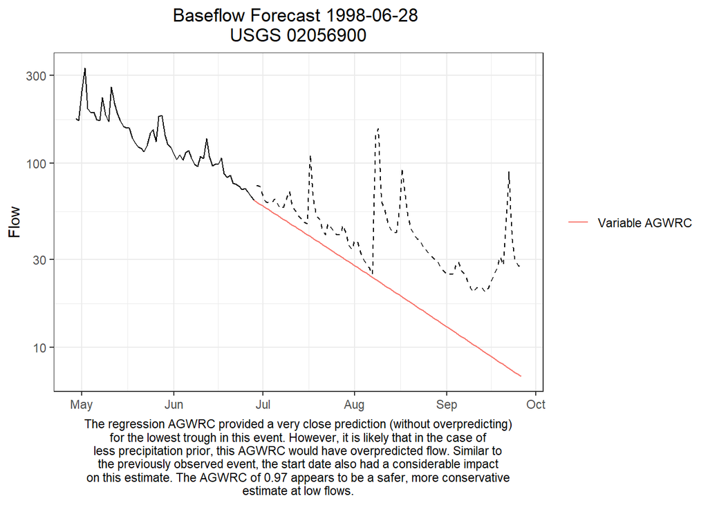

[3 more figures not shown]

## QC Metrics

There are **41** identified baseflow events at this gage. The number of identified baseflow events is dependent on the record length of the gage; older gages have more identified baseflow events. Additionally, ten baseflow events have been deemed the appropriate number of baseflow events to perform reasonable analysis.

**Table 8.** Number of baseflow events per month for USGS 02056900

| Month | Number of BF Events |
| --- | --- |
| January | 3 |
| February | 2 |
| March | 7 |
| April | 5 |
| May | 4 |
| June | 5 |
| July | 1 |
| August | 3 |
| September | 3 |
| October | 3 |
| November | 3 |
| December | 2 |

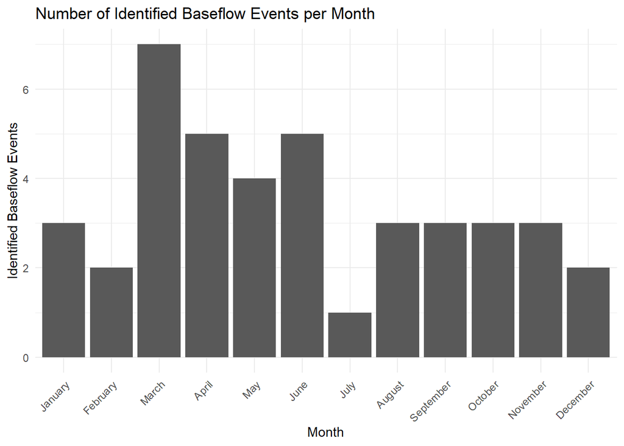

**Figure 13.** Number of identified baseflow events per month for USGS 02056900

**Table 9.** Other relevant QC metrics. The Breusch–Pagan test and the White test are statistical methods to quantify heteroscedasticity (when the variability of the dependent variable is not constant). Both tests check for heteroskedasticity; the Breusch–Pagan test assumes normal residuals and detects linear heteroscedasticity while the White test is more general and detects both linear and nonlinear heteroskedasticity. A significant p-value (less than 0.05) suggests sufficient evidence for heteroskedasticity in the flow data. The recorded flow values indicate the gage length, or the total number of non-NA flow values recorded over the entire date range of data collection. The watershed slope is the average slope in the entire drainage basin expressed as a percentage of the vertical rise over the the horizontal distance.

| White Test p-value | Breush-Pagan p-value | Recorded Flow Values | Watershed Slope (%) |
| --- | --- | --- | --- |
| 0.1538 | 0.0788 | 18199 | 19.32 |